# Загрузки статистики из рекламных аккаунтов Facebook

Алексей Селезнёв

2019-06-19

Для загрузки статистических данных из рекламных аккаунтов Facebook в пакете `rfacebookstat` необходимо использовать функцию `fbGetMarketingStat`.

## Аргументы функции `fbGetMarketingStat`

Функция имеет множество аргументов с помощью которых вы можете максимально точно обозначить формат получаемых из API Facebook данных.

- *accounts_id* - ID рекламных аккаунтов, перед ID необходимо указать префикс `act_`, вы можете указать вектор из ID аккаунтов если требуется загрузить данные из набора аккаунтов. По умолчанию запрашивает значение опции *rfacebookstat.accounts_id*.
- *sorting* - Поле для сортировки полученных данных, так же вы можете указать направление добавив "_ascending" или "_descending" в поле сортировки. Например “reach_descending”. Для действий вы можете сортировать по типу действия в форме “actions: ”. Например, [“actions: link_click_ascending”]. Вы можете задать только одно поле для сортировки.
- *level* - Уровень группировки данных, принимает одно из следующих значений: ad, adset, campaign, account. По умолчанию имеет значение account.
- *action_breakdowns* - Разбивки по действиям, более подробно о них можно узнать в [документации](https://developers.facebook.com/docs/marketing-api/insights/breakdowns#actionsbreakdown) к API Facebook, так же более подробно они будут рассмотрены позже в этой виньетке.
- *breakdowns* - Общие разбивки которые предоставляют дополнительные возможности по группировке данных, подробности в [документации](https://developers.facebook.com/docs/marketing-api/insights/breakdowns#ageandgender) к API Facebook, так же этот аргумент будет более подробно рассмотрен немного ниже.
- *fields* - Поля которые вы хотите загрузить из API, полный список всех полей доступен по [ссылке](https://developers.facebook.com/docs/marketing-api/insights/parameters#fields).
- *filtering* - Текстовая строка или вектор. Филтрацию отчёта вы можете задавать либо в JSON формате либо в упрощенном формате, более подробно о фильтрации будет написано немного ниже.
- *date_start* - Дата начала отчётного периода.
- *date_stop* - Дата завершения рабочего отчётного периода.
- *request_speed* - Скорость отправки запросов, возможные значения “normal”, “fast” или “slow”. Так же можно задать числовое значение, которое будет задавть количество секунд в паузе между отправкой запросов к API.
- *api_version* - Версия API к которой будет отвравлен запрос, по умолчанию берётся хначение из опции *rfacebookstat.api_version*.
- *action_report_time* - Допустимые значения: impression, conversion. Определяет отчет о времени действия статистики. Например, если человек видел объявление 1 января, но совершил конверсию 2 января, при запросе API с `action_report_time = "impression"`, вы увидите конверсию 1 января. Когда вы запросите API с помощью `action_report_time = "conversion"`, вы увидите преобразование 2 января.
- *interval* - Группировка по временному интервалу, возможные значения: day, week, month, quarter, year.
- *console_type* - Тип выводимых в консоль данных, возможные значения progressbar, message.
- *access_token* - Токен доступа к API полученный с помощью функции `fbGetToken`, по умолчанию запрашивается значение опции. *rfacebookstat.access_token*

## Пример запроса статистики

```r
library(rfacebookstat)

options(rfacebookstat.access_token = "ваш токен",
        rfacebookstat.accounts_id  = "act_000000000")

fb_data <- fbGetMarketingStat(
                  level              = "campaign",
                  fields             = "campaign_name,
                                        impressions,
                                        clicks,
                                        spend,
                                        actions",
                  date_start         = "2019-05-01",
                  date_stop          = "2019-05-10")
```

Выше приведён простейший способ загрузки стастистики по показам, кликам, тратам и действиям в разреще дней и рекламных кампаний. Использование опций *rfacebookstat.access_token* и *rfacebookstat.accounts_id* не является обязательным, но поможет вам избежать дублирование этих параметров в аргументах всех функций пакета, поэтому я рекомендую именно такой способ установки значений accout_id, access_token, business_id и api_version.

## Разбивки (breakdowns)

Разивки помогают помогают обогощать ваши данные за счёт дополнительных полей и группировок, на данный момент поддерживаются следующие разбивки:

- ad_format_asset
- age
- body_asset
- call_to_action_asset
- country
- description_asset
- gender
- image_asset
- impression_device
- link_url_asset
- product_id
- region
- title_asset
- video_asset
- dma
- frequency_value
- hourly_stats_aggregated_by_advertiser_time_zone
- hourly_stats_aggregated_by_audience_time_zone
- place_page_id
- publisher_platform
- platform_position
- device_platform

Актульный список группировок всегда можно найти в официальной документации API Facebook по [ссылке](https://developers.facebook.com/docs/marketing-api/insights/breakdowns#ageandgender).

```r
library(rfacebookstat)

options(rfacebookstat.access_token = "ваш токен",
        rfacebookstat.accounts_id  = "act_000000000")

fb_data_breakdowns <- fbGetMarketingStat(
  level              = "campaign",
  fields             = "campaign_name,
                        impressions,
                        clicks,
                        spend,
                        actions",
  breakdowns         = "region",
  date_start         = "2019-05-01",
  date_stop          = "2019-05-10")
```

## Разбивки по действиям (action_breakdowns)

Вы можете сгруппировать результаты в поле *actions*. Аргумент *action_breakdowns* позволяет применить указанные ниже разбивки.

- action_device - Устройство, на котором произошло отслеживаемое событие конверсии. Например, «ПК», если человек выполнил конверсию с ПК.
- action_destination - Куда переходят люди, нажав вашу рекламу. Это может быть ваша Страница Facebook, внешний URL-адрес пикселя конверсий или приложение, сконфигурированное с помощью комплекта разработчика ПО.
- action_reaction - Количество реакций на ваши объявления или продвигаемые публикации. Кнопка реакций в рекламе позволяет людям по-разному отреагировать на ее содержание. Можно выбрать “Нравится”, “Супер”, “Ха-ха”, “Ух ты!”, “Сочувствую” или “Возмутительно”.
- action_target_id - Идентификатор места назначения, в которое переходят люди, нажавшие на ссылку в вашей рекламе. Это может быть ваша Страница Facebook, внешний URL вашего пикселя конверсий, или приложение, сконфигурированное с помощью SDK.
- action_type - Тип действий, выполненных в отношении вашей рекламы, Страницы, приложения или мероприятия после показа объявления кому-либо, даже если эти люди не нажимали объявления. Типы действий включают отметки «Нравится» Страницы, установки приложений, конверсии, ответы на мероприятия и т.д.

```r
library(rfacebookstat)

options(rfacebookstat.access_token = "ваш токен",
        rfacebookstat.accounts_id  = "act_000000000")

fb_data_action_breakdowns <- fbGetMarketingStat(
  level              = "campaign",
  fields             = "campaign_name,
                        impressions,
                        clicks,
                        spend,
                        actions",
  action_breakdowns  = "action_reaction",
  date_start         = "2019-05-01",
  date_stop          = "2019-05-10")
```

### Описание полей возвращаемых в ращбивке action_type

- app_custom_event.fb_mobile_achievement_unlocked: Разблокированные функции в мобильном приложении
- app_custom_event.fb_mobile_activate_app: Запуски мобильного приложения
- app_custom_event.fb_mobile_add_payment_info: Сведения об оплате в мобильном приложении
- app_custom_event.fb_mobile_add_to_cart: Добавления в корзину в мобильном приложении
- app_custom_event.fb_mobile_add_to_wishlist: Добавления в список желаний в мобильном приложении
- app_custom_event.fb_mobile_complete_registration: Регистрации в мобильном приложении
- app_custom_event.fb_mobile_content_view: Просмотры материалов мобильного приложения
- app_custom_event.fb_mobile_initiated_checkout: Оформление заказов в мобильном приложении
- app_custom_event.fb_mobile_level_achieved: Достижения в мобильном приложении
- app_custom_event.fb_mobile_purchase: Покупки в мобильном приложении
- app_custom_event.fb_mobile_rate: Оценки в мобильном приложении
- app_custom_event.fb_mobile_search: Поисковые запросы в мобильном приложении
- app_custom_event.fb_mobile_spent_credits: Траты кредитов в мобильном приложении
- app_custom_event.fb_mobile_tutorial_completion: Использования обучающей программы в мобильном приложении
- app_custom_event.other: Другие действия в мобильном приложении
- app_install: Установки приложения
- app_use: Использования приложения
- checkin: Посещения
- comment: Комментарии к публикации
- credit_spent: Траты кредитов
- games.plays: Количество раз, когда играли в вашу игру
- landing_page_view: Просмотры целевой страницы
- leadgen.other: Лиды (Форма)
- like: Отметки «Нравится» Страницы
- link_click: Количество кликов на ссылку
- mobile_app_install: Установки мобильного приложения
- offsite_conversion.custom.: Индивидуально настроенные рекламодателем конверсии
- offsite_conversion.fb_pixel_add_payment_info: Добавление платежной информации
- offsite_conversion.fb_pixel_add_to_cart: Добавления товаров в корзину
- offsite_conversion.fb_pixel_add_to_wishlist: Добавления в список пожеланий
- offsite_conversion.fb_pixel_complete_registration: Завершенная регистрация
- offsite_conversion.fb_pixel_custom: Специально настроенные события пикселя, заданные рекламодателем
- offsite_conversion.fb_pixel_initiate_checkout: Инициирует оформление заказа
- offsite_conversion.fb_pixel_lead: Потенциальные клиенты
- offsite_conversion.fb_pixel_purchase: Покупки
- offsite_conversion.fb_pixel_search: Поиск
- offsite_conversion.fb_pixel_view_content: Просматривает контент
- onsite_conversion.flow_complete: Завершенные рабочие процессы на Facebook
- onsite_conversion.messaging_block: Заблокированные переписки
- onsite_conversion.messaging_conversation_started_7d: Начата переписка
- onsite_conversion.messaging_first_reply: Новые переписки
- onsite_conversion.post_save: Сохранения публикации
- onsite_conversion.purchase: Покупки на Facebook
- outbound_click: Исходящие клики
- photo_view: Отметки фотографии Страницы
- post: Репосты публикации
- post_reaction: Реакции на публикацию
- rsvp: Ответы на мероприятие
- video_view: 3-секундные просмотры видео

## Применить одновременно несколько разбивок

Некоторые разбивки можно применять одновременно. Типы группирования, помеченные звездочкой (*), можно объединить с action_type, action_target_id и action_destination (название action_target_id).

- action_type *
- action_target_id *
- action_device *
- action_device, impression_device *
- action_device, publisher_platform *
- action_device, publisher_platform, impression_device *
- action_device, publisher_platform, platform_position *
- action_device, publisher_platform, platform_position, impression_device *
- action_reaction
- action_type, action_reaction
- age *
- gender *
- age, gender *
- country *
- region *
- publisher_platform *
- publisher_platform, impression_device *
- publisher_platform, platform_position *
- publisher_platform, platform_position, impression_device *
- product_id *

## Фильтрация данных

Вы можете применять фильтры к запрашиваемым данным. Использовать для этого необходимо аргумент `filtering`. Указывать выражение для фильтрации ы можете в упрошённом формате или в виде JSON объектов, ниже я приведу пример использования обоих вариантов.

Для фильтрации вам необходимо указать поле по которому вы будете фильтровать данные, оператор и значение. Допустимые операторы для фильтрации: EQUAL, NOT_EQUAL, GREATER_THAN, GREATER_THAN_OR_EQUAL, LESS_THAN, LESS_THAN_OR_EQUAL, IN_RANGE, NOT_IN_RANGE, CONTAIN, NOT_CONTAIN, IN, NOT_IN, STARTS_WITH, ANY, ALL, AFTER, BEFORE, NONE

### Пример фильтрации в упрощенном формате

```r
library(rfacebookstat)

options(rfacebookstat.access_token = "ваш токен",
        rfacebookstat.accounts_id  = "act_000000000")
fb_data <- fbGetMarketingStat(
  level              = "campaign",
  fields             = "campaign_name,
                        impressions,
                        clicks,
                        spend,
                        actions",
  filtering          = "impressions LESS_THAN 5000",
  date_start         = "2019-05-01",
  date_stop          = "2019-05-10")
```

В приведённом примере мы указали фильтр `impressions LESS_THAN 5000` и таким образом оставили строки в которых поле impressions имеет значение менее 5000.

Если вам необходимо использовать множественный оператор (IN_RANGE, NOT_IN_RANGE, IN, NOT_IN) то в упрошенном формате запись будет выглядеть так: `"publisher_platform IN instagram,facebook"`. Важно не ставить проблемы между списком значений.

```r
library(rfacebookstat)

options(rfacebookstat.access_token = "ваш токен",
        rfacebookstat.accounts_id  = "act_000000000")
fb_data <- fbGetMarketingStat(
  level              = "campaign",
  fields             = "campaign_name,
                        impressions,
                        clicks,
                        spend,
                        actions",
  filtering          = "publisher_platform IN instagram,facebook",
  breakdowns         = "publisher_platform",
  date_start         = "2019-05-01",
  date_stop          = "2019-05-10")
```

Если вы хотите применить несколько фиьтров то вы можете передать в аргумент `filtering` вектор из выражений, например: `c("clicks LESS_THAN 500", "impressions GREATER_THAN 1000")`.

```r
library(rfacebookstat)

options(rfacebookstat.access_token = "ваш токен",
        rfacebookstat.accounts_id  = "act_000000000")
fb_data <- fbGetMarketingStat(
  level              = "campaign",
  fields             = "campaign_name,
                        impressions,
                        clicks,
                        spend,
                        actions",
  filtering          = c("clicks LESS_THAN 500", "impressions GREATER_THAN 1000"),
  date_start         = "2019-05-01",
  date_stop          = "2019-05-10")
```

### Пример фильтрации в JSON формате

Как я уже писал выше вы можете описывать фильтры в виде JSON объектов, но такая запись будет более громозка. Давайте приведу вам аналогию с представленными выше фильтрами.

Упрошённый формат: `"impressions LESS_THAN 5000"`

JSON: `"[{"field":"impressions","operator":"LESS_THAN","value":"5000"}]"`

Упрошённый формат: `"publisher_platform IN instagram,facebook"`

JSON: `[{"field":"publisher_platform","operator":"IN","value":["instagram","facebook"]}]`

Упрошённый формат: `c("clicks LESS_THAN 500", "impressions GREATER_THAN 1000")`

JSON: `[{"field":"clicks","operator":"LESS_THAN","value":"500"},{"field":"impressions","operator":"GREATER_THAN","value":"1000"}]`

## Лимиты API и аргумент request_speed

По использованию аргумента `request_speed` есть целая [статья](https://bit.ly/2JS8hon), но я всё же немного опишу зачем данный аргумент нужен.

В API Facebook на данный момент существует 2 уровня доступа к API ([раздел в справке](https://developers.facebook.com/docs/marketing-api/access) API Facebook):

- Разработка- Тестирование приложений с помощью API.
- Стандартный уровень доступа для управления рекламой - Дополнительные ресурсы, например менее строгие ограничения количества обращений, а также возможность принять участие в программе для партнеров Facebook.

По умолчанию все создаваемые вами приложения получают уровень “Разработка”. Данный уровень имеет серьёзные ограничения на количество отправляемых в API запросов. Функция `fbGetMarketingStat` при использовании аргумента `interval` равным `"day"` загружает данные по дням, и на каждый день отправляет отделый запрос в API.

В случае если вы имеете стандартный доступ то для вас это не будет проблемой и вы можете установить `request_speed = "fast"`, но для приложений с уровнем доступа “Разработка” такой объём отправляемых запросов может выйти далеко за лимиты API, от части `fbGetMarketingStat` умеет обходить такие лимиты каждый раз уходя в бан при их привышении, но скорость загрузки данных при попадает в бан будет очень низкий, иногда бан может составлять 5 минут.

Поэтому если ваше приложение имеет уровень доступа “Разработке” при загрузке данных по дням за длительный период рекомендуется использовать `request_speed = "slow"`. Если значениеи “slow” помогает вы можете самостоятельно задавать паузу в секундах между запросами, например `request_speed = 4` будет задавать 4 секундую паузу между отправкой запросов.

Для получения стандартного доступа требуется перейти в [ваше приложение](https://developers.facebook.com/apps/) в раздел настроек API Marketing и отправить заявку на “Ads Management Standart Access”.

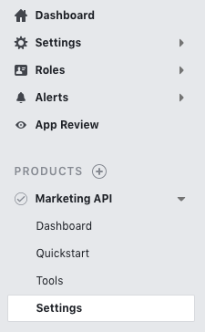

Приложение

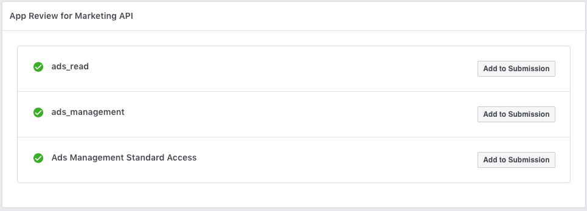

Приложение